# LDA y Árboles de Decisión

## Definición del problema

El objetivo de este trabajo es comparar el desempeño de Linear Discriminant Analysis (LDA) y un árbol de decisión usando una base de datos del UCI Machine Learning Repository para clasificar a los estudiantes según la escuela a la que pertenecen. En la Tabla 1, se puede observar una vista previa del conjunto de datos de la base de datos, donde se observan 33 variables en total.

La variable de salida es 'school', la cual contiene dos clases, GP y MS. Es importante mencioanr que para construir los modelos no se utilizaron las 33 variables, por lo que solamente se utilizaron las variables 'age', 'studytime', 'failures', 'absences', 'G1', 'G2' y 'G3'. Estas variables representan características como la edad, el tiempo de estudio, materias reprobadas, ausencias y calificaciones en los diferentes parciales de los estudiantes. Asimismo, estas variables se muestran en la Tabla 2.

Ambos modelos utilizaron las mismas variables y la misma partición de datos para hacer una comparación equitatitva.

```python
import pandas as pd
import numpy as np
import matplotlib.pyplot as plt
import seaborn as sns

from IPython.display import display

from sklearn.model_selection import (
    train_test_split,
    StratifiedKFold,
    cross_val_score
)

from sklearn.pipeline import make_pipeline
from sklearn.preprocessing import StandardScaler
from sklearn.discriminant_analysis import LinearDiscriminantAnalysis
from sklearn.tree import DecisionTreeClassifier, plot_tree

from sklearn.metrics import (
    confusion_matrix,
    classification_report,
    accuracy_score,
    balanced_accuracy_score,
    precision_score,
    recall_score,
    f1_score,
    roc_auc_score,
    roc_curve
)


data = pd.read_csv("student-por.csv", sep=";")

data.head(10).style\
    .hide(axis="index")\
    .set_properties(**{"text-align": "center"})\
    .set_table_styles([
        {"selector": "th", "props": [("text-align", "center")]}
    ])\
    .set_caption("[TABLA 1]. Vista previa del conjunto de datos.")
```

[TABLA 1]. Vista previa del conjunto de datos.

| school | sex | age | address | famsize | Pstatus | Medu | Fedu | Mjob | Fjob | reason | guardian | traveltime | studytime | failures | schoolsup | famsup | paid | activities | nursery | higher | internet | romantic | famrel | freetime | goout | Dalc | Walc | health | absences | … |
| --- | --- | --- | --- | --- | --- | --- | --- | --- | --- | --- | --- | --- | --- | --- | --- | --- | --- | --- | --- | --- | --- | --- | --- | --- | --- | --- | --- | --- | --- | --- |
| GP | F | 18 | U | GT3 | A | 4 | 4 | at_home | teacher | course | mother | 2 | 2 | 0 | yes | no | no | no | yes | yes | no | no | 4 | 3 | 4 | 1 | 1 | 3 | 4 | … |
| GP | F | 17 | U | GT3 | T | 1 | 1 | at_home | other | course | father | 1 | 2 | 0 | no | yes | no | no | no | yes | yes | no | 5 | 3 | 3 | 1 | 1 | 3 | 2 | … |
| GP | F | 15 | U | LE3 | T | 1 | 1 | at_home | other | other | mother | 1 | 2 | 0 | yes | no | no | no | yes | yes | yes | no | 4 | 3 | 2 | 2 | 3 | 3 | 6 | … |
| GP | F | 15 | U | GT3 | T | 4 | 2 | health | services | home | mother | 1 | 3 | 0 | no | yes | no | yes | yes | yes | yes | yes | 3 | 2 | 2 | 1 | 1 | 5 | 0 | … |
| GP | F | 16 | U | GT3 | T | 3 | 3 | other | other | home | father | 1 | 2 | 0 | no | yes | no | no | yes | yes | no | no | 4 | 3 | 2 | 1 | 2 | 5 | 0 | … |
| GP | M | 16 | U | LE3 | T | 4 | 3 | services | other | reputation | mother | 1 | 2 | 0 | no | yes | no | yes | yes | yes | yes | no | 5 | 4 | 2 | 1 | 2 | 5 | 6 | … |
| GP | M | 16 | U | LE3 | T | 2 | 2 | other | other | home | mother | 1 | 2 | 0 | no | no | no | no | yes | yes | yes | no | 4 | 4 | 4 | 1 | 1 | 3 | 0 | … |
| GP | F | 17 | U | GT3 | A | 4 | 4 | other | teacher | home | mother | 2 | 2 | 0 | yes | yes | no | no | yes | yes | no | no | 4 | 1 | 4 | 1 | 1 | 1 | 2 | … |
| GP | M | 15 | U | LE3 | A | 3 | 2 | services | other | home | mother | 1 | 2 | 0 | no | yes | no | no | yes | yes | yes | no | 4 | 2 | 2 | 1 | 1 | 1 | 0 | … |
| GP | M | 15 | U | GT3 | T | 3 | 4 | other | other | home | mother | 1 | 2 | 0 | no | yes | no | yes | yes | yes | yes | no | 5 | 5 | 1 | 1 | 1 | 5 | 0 | … |

```python
variables = [
    "age",
    "studytime",
    "failures",
    "absences",
    "G1",
    "G2",
    "G3"
]

data2 = data[["school"] + variables].dropna()

X = data2[variables]
y = data2["school"]

display(
    data2.head(10).style
    .hide(axis="index")
    .set_properties(**{"text-align": "center"})
    .set_table_styles([
        {
            "selector": "th",
            "props": [("text-align", "center")]
        }
    ])
    .set_caption(
        "[TABLA 2]. Variables utilizadas para construir el modelo LDA."
    )
)
```

[TABLA 2]. Variables utilizadas para construir el modelo LDA.

| school | age | studytime | failures | absences | G1 | G2 | G3 |
| --- | --- | --- | --- | --- | --- | --- | --- |
| GP | 18 | 2 | 0 | 4 | 0 | 11 | 11 |
| GP | 17 | 2 | 0 | 2 | 9 | 11 | 11 |
| GP | 15 | 2 | 0 | 6 | 12 | 13 | 12 |
| GP | 15 | 3 | 0 | 0 | 14 | 14 | 14 |
| GP | 16 | 2 | 0 | 0 | 11 | 13 | 13 |
| GP | 16 | 2 | 0 | 6 | 12 | 12 | 13 |
| GP | 16 | 2 | 0 | 0 | 13 | 12 | 13 |
| GP | 17 | 2 | 0 | 2 | 10 | 13 | 13 |
| GP | 15 | 2 | 0 | 0 | 15 | 16 | 17 |
| GP | 15 | 2 | 0 | 0 | 12 | 12 | 13 |

## Distribución general de las clases

La base de datos tiene 649 observaciones. De las cuales, 423 estudiantes pertenecen a GP, lo que representa el 65.18% de los datos, mientras que 226 pertenecen a MS, equivalente al 34.82%. Este desbalance moderado de las clases se observa en la Tabla 3.

Debido a que existe un desbalance importante, el modelo entonces puede obtener una exactitud elevada al favorecer constantemente a la clase mayoritaria. Por esta razón, además de la exactitud general, se utilizaron métricas como exactitud balanceada, sensibilidad, especificidad, F1-Score y ROC-AUC.

```python
conteo_clases = y.value_counts().sort_index()
porcentaje_clases = y.value_counts(
    normalize=True
).sort_index() * 100

tabla_balance_general = pd.DataFrame({
    "Clase": conteo_clases.index,
    "Cantidad": conteo_clases.values,
    "Porcentaje": porcentaje_clases.values
})

display(
    tabla_balance_general.style
    .hide(axis="index")
    .format({
        "Porcentaje": "{:.2f}%"
    })
    .set_properties(**{"text-align": "center"})
    .set_caption(
        "[TABLA 3]. Distribución general de las clases."
    )
)
```

[TABLA 3]. Distribución general de las clases.

| Clase | Cantidad | Porcentaje |
| --- | --- | --- |
| GP | 423 | 65.18% |
| MS | 226 | 34.82% |

## Partición de los datos

Los datos se divieron en 70% para entrenamiento y 30% para prueba. Se utilizó una partición estratificada para conservar aproximadamente la proporción original de las clases en ambos subconjuntos.

El conjunto de entrnamiento quedó formado por 296 estudiantes de GP y 158 de MS. El conjunto de prueba contiene 127 estudiantes de GP y 68 de MS. De esta manera, el modelo se entrenó con una distribución semejante a la que posteriormente se utilizó para evaluar su desempeño.

```python
X_train, X_test, y_train, y_test = train_test_split(
    X,
    y,
    test_size=0.30,
    stratify=y,
    random_state=27
)
```

```python
tabla_distribucion = pd.DataFrame({
    "Datos completos": y.value_counts().sort_index(),
    "Entrenamiento": y_train.value_counts().sort_index(),
    "Prueba": y_test.value_counts().sort_index()
}).fillna(0).astype(int)

tabla_distribucion.index.name = "Clase"
tabla_distribucion = tabla_distribucion.reset_index()

display(
    tabla_distribucion.style
    .hide(axis="index")
    .set_properties(**{"text-align": "center"})
    .set_caption(
        "[TABLA 4]. Distribución de clases."
    )
)
```

[TABLA 4]. Distribución de clases.

| Clase | Datos completos | Entrenamiento | Prueba |
| --- | --- | --- | --- |
| GP | 423 | 296 | 127 |
| MS | 226 | 158 | 68 |

## Modelo LDA

El primer modelo utilizado fue LDA. Antes del entrenamiento, las clases fueron estandarizadas para evitar que sus escalas influyeran en el modelo. LDA busca encontrar una combinación lineal de las variables que permita separar las clases GP y MS.

LDA funciona mejor cuando los datos de cada clase tienen una distribución parecida a la normal y una variación similar. Algunas variables, como 'studytime' y 'failures' pueden no cumplir completamente conestas condiciones, pero el modelo todavía permite analizar si es posible separar las dos clases utilizando una frontera lineal.

La clase negativa se tomará como GP y la clase positiva se tomará como MS.

```python
# Predicciones y probabilidades de prueba
pred_lda = modelo_lda.predict(X_test)
prob_lda = modelo_lda.predict_proba(X_test)

# Clases del modelo
clases_lda = modelo_lda.classes_

# Se toma la segunda clase como positiva
clase_negativa = clases_lda[0]
clase_positiva = clases_lda[1]

indice_positivo = np.where(
    clases_lda == clase_positiva
)[0][0]

prob_positiva_lda = prob_lda[:, indice_positivo]

print("Clase negativa:", clase_negativa)
print("Clase positiva:", clase_positiva)
```

```
Clase negativa: GP
Clase positiva: MS
```

### Función discriminante LD1

Debido a que el problema contiene dos clases, LDA genera una sola función discriminante, denominada LD1. La Gráfica 1 muestra que GP tiende a concentrarse en valores menores de LD1, mientras que MS cuenta con una mayor concentración en valores positivos.

Sin embargo, se puede observar una superposición considerable entre las distribuciones. Esto significa que LDA encuentra cierta separación entre las escuelas, pero la frontera lineal no es suficiente para distinguir correctamente todos los casos. Esta superposición se refleja posteriormente en la cantidad de estudiantes de MS que el modelo clasifica como GP.

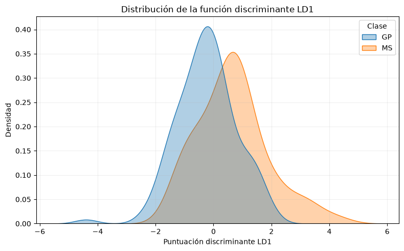

```python
escalador = modelo_lda.named_steps["standardscaler"]
lda = modelo_lda.named_steps["lineardiscriminantanalysis"]

X_train_escalado = escalador.transform(X_train)
X_test_escalado = escalador.transform(X_test)

ld_train = lda.transform(X_train_escalado)[:, 0]
ld_test = lda.transform(X_test_escalado)[:, 0]

tabla_ld_test = pd.DataFrame({
    "LD1": ld_test,
    "Clase": y_test.to_numpy()
})

plt.figure(figsize=(8, 5))

sns.kdeplot(
    data=tabla_ld_test,
    x="LD1",
    hue="Clase",
    fill=True,
    common_norm=False,
    alpha=0.35
)

plt.title("Distribución de la función discriminante LD1")
plt.xlabel("Puntuación discriminante LD1")
plt.ylabel("Densidad")
plt.grid(alpha=0.2)
plt.tight_layout()
plt.show()
```

[GRÁFICA 1]. Distribución de la función discriminante LD1.

### Coeficientes del LDA

De acuerdo con la magnitud absoluta de los coeficientes, las variables con mayor influencia en la función discriminante fueron 'G1' con un valor de 0.6363, 'absences' con 0.5127, y 'G3' con 0.3803. Por otro lado, la variable con menor magnitud fue de 'failures' con un valor de 0.0650, por lo que casi no realizó alguna contribución a la separación lineal.

Los coeficientes negativos de 'G1', 'absences', 'G3' y 'studytime' orientan la función hacia la clase 'GP', mientras que los coeficientes positivos de 'age' y 'G2' la orientan hacia 'MS'. Sin embargo, estos resultados se tienen que tomar con cuidado debido a que G1, G2 y G3 tienen una alta colinealidad entre ellos.

```python
tabla_coeficientes_lda = pd.DataFrame({
    "Variable": variables,
    "Coeficiente LDA": lda.coef_[0],
    "Magnitud absoluta": np.abs(lda.coef_[0])
}).sort_values(
    "Magnitud absoluta",
    ascending=False
)

display(
    tabla_coeficientes_lda.style
    .hide(axis="index")
    .format({
        "Coeficiente LDA": "{:.4f}",
        "Magnitud absoluta": "{:.4f}"
    })
    .set_properties(**{"text-align": "center"})
    .set_caption(
        "[TABLA 5]. Coeficientes de la función discriminante."
    )
)
```

[TABLA 5]. Coeficientes de la función discriminante.

| Variable | Coeficiente LDA | Magnitud absoluta |
| --- | --- | --- |
| G1 | -0.6363 | 0.6363 |
| absences | -0.5127 | 0.5127 |
| G3 | -0.3803 | 0.3803 |
| age | 0.2601 | 0.2601 |
| G2 | 0.2168 | 0.2168 |
| studytime | -0.1830 | 0.1830 |
| failures | -0.0650 | 0.0650 |

### Matriz de confusión

EL modelo clasificó correctamente a 108 de los 127 estudiantes de 'GP' y 24 de los 68 estudiantes de 'MS'. También clasificó incorrectamente 19 estudiantes de GP como MS y 44 estudiantes de MS como GP. Por lo tanto, el problema principal del LDA fue la cantidad elevada de falsos negativos para MS.

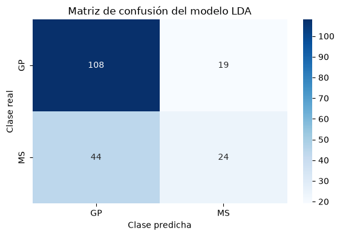

```python
from sklearn.metrics import confusion_matrix

cm_lda = confusion_matrix(
    y_test,
    pred_lda,
    labels=[clase_negativa, clase_positiva]
)

plt.figure(figsize=(6, 4))

sns.heatmap(
    cm_lda,
    annot=True,
    fmt="d",
    cmap="Blues",
    xticklabels=[clase_negativa, clase_positiva],
    yticklabels=[clase_negativa, clase_positiva]
)

plt.title("Matriz de confusión del modelo LDA")
plt.xlabel("Clase predicha")
plt.ylabel("Clase real")
plt.tight_layout()
plt.show()
```

[GRÁFICA 2]. Matriz de confusión del modelo LDA.

### Evalución del LDA

En la Tabla 6, se observa que el modelo LDA obtuvo una exactitud de 0.6769, lo que significa que clasificó correctamente aproximadamente el 67.69% de las observaciones de prueba. Su exactitud balanceada fue de 0.6017, un valor más chico debido a la diferencia en el desempeño entre las dos clases.

Para la clase positiva MS, el modelo alcanzó una precisión de 0.5581 una sensibilidad de 0.3529. Esto significa que, de todos los estudiantes clasificados como MS, el 55.81% realmente pertenecía a esta escuela, sin embargo, solamente se identificó correctamente el 35.29% de todos los estudiantes de MS. La especificidad fue de 0.8504, mostrando que el modelo presentó mayor facilidad para reconocer estudiantes de GP. Esto se comprueba con la matriz de confusión presentada anteriormente en la Gráfica 2.

El F1-Score de MS fue de 0.4324, reflejando el desempeño moderado del modelo al combinar precisión y sensibilidad. Finalmente, el ROC-AUC fue de 0.7142, lo que demuestra que este análisis del LDA tiene una capacidad aceptable pero limitada para diferenciar entre las dos clases a través de diferentes umbrales.

```python
from sklearn.metrics import (
    accuracy_score,
    precision_score,
    recall_score,
    f1_score,
    roc_auc_score,
    balanced_accuracy_score
)

# Convertir las clases a 0 y 1
y_test_binaria = (
    y_test.to_numpy() == clase_positiva
).astype(int)

pred_lda_binaria = (
    pred_lda == clase_positiva
).astype(int)

# Extraer los elementos de la matriz
tn, fp, fn, tp = cm_lda.ravel()

# Calcular métricas
accuracy_lda = accuracy_score(
    y_test_binaria,
    pred_lda_binaria
)

accuracy_balanceada_lda = balanced_accuracy_score(
    y_test_binaria,
    pred_lda_binaria
)

precision_lda = precision_score(
    y_test_binaria,
    pred_lda_binaria,
    zero_division=0
)

sensibilidad_lda = recall_score(
    y_test_binaria,
    pred_lda_binaria,
    zero_division=0
)

especificidad_lda = (
    tn / (tn + fp)
    if (tn + fp) > 0
    else 0
)

f1_lda = f1_score(
    y_test_binaria,
    pred_lda_binaria,
    zero_division=0
)

auc_lda = roc_auc_score(
    y_test_binaria,
    prob_positiva_lda
)
```

```python
tabla_metricas_lda = pd.DataFrame({
    "Métrica": [
        "Exactitud",
        "Exactitud balanceada",
        "Precisión",
        "Sensibilidad",
        "Especificidad",
        "F1-score",
        "ROC-AUC"
    ],
    "Resultado": [
        accuracy_lda,
        accuracy_balanceada_lda,
        precision_lda,
        sensibilidad_lda,
        especificidad_lda,
        f1_lda,
        auc_lda
    ]
})

display(
    tabla_metricas_lda.style
    .hide(axis="index")
    .format({
        "Resultado": "{:.4f}"
    })
    .set_properties(**{"text-align": "center"})
    .set_caption(
        "[TABLA 6]. Métricas del modelo LDA en datos de prueba."
    )
)
```

[TABLA 6]. Métricas del modelo LDA en datos de prueba.

| Métrica | Resultado |
| --- | --- |
| Exactitud | 0.6769 |
| Exactitud balanceada | 0.6017 |
| Precisión | 0.5581 |
| Sensibilidad | 0.3529 |
| Especificidad | 0.8504 |
| F1-score | 0.4324 |
| ROC-AUC | 0.7142 |

La tabla 7 muestra que el modelo LDA funciona considerablemente mejor para identificar estudiantes de GP que de MS.

Para GP se obtuvo que su precisión fue de 0.7105, lo que significa que de todos los estudiantes clasificados como GP, el 71.05% realmente pertenecía a GP. Asimismo, se obtuvo un recall de 0.8504, lo que indica que el modelo identificó correctamente al 85.04% de los estudiantes que realmente eran de GP. Su F1-score de 0.7742 demuestra un desempeño relativamente bueno para esta clase.

Para MS, se obtuvo una precisión de 0.5581, es decir que los estudiantes que fueron clasificados como MS, el 55.81% realmente pertenecía a MS. Se obtuvo un recall de 0.3529, lo que indica que el modelo solamente identificó al 35.29% de los estudiantes que realmente eran de MS. Su F1-score de 0.4324 indica un desempeño bajo para esta clase.

```python
from sklearn.metrics import classification_report

reporte_lda = classification_report(
    y_test,
    pred_lda,
    labels=clases_lda,
    output_dict=True,
    zero_division=0
)

tabla_reporte_lda = pd.DataFrame(
    reporte_lda
).transpose()

display(
    tabla_reporte_lda.style
    .format({
        "precision": "{:.4f}",
        "recall": "{:.4f}",
        "f1-score": "{:.4f}",
        "support": "{:.0f}"
    })
    .set_properties(**{"text-align": "center"})
    .set_caption(
        "[TABLA 7]. Reporte de clasificación del modelo LDA."
    )
)
```

[TABLA 7]. Reporte de clasificación del modelo LDA.

|  | precision | recall | f1-score | support |
| --- | --- | --- | --- | --- |
| GP | 0.7105 | 0.8504 | 0.7742 | 127 |
| MS | 0.5581 | 0.3529 | 0.4324 | 68 |
| accuracy | 0.6769 | 0.6769 | 0.6769 | 1 |
| macro avg | 0.6343 | 0.6017 | 0.6033 | 195 |
| weighted avg | 0.6574 | 0.6769 | 0.6550 | 195 |

## Árbol de decisión

### Árbol de decisión sin poda

Ahora, se construyó un árbol de decisión utilizando el criterio Gini. Inicialmente no se estableció un límite de profundidad ni se aplicó poda, por lo que el árbol continuó creciendo hasta alcanzar las condiciones de detención del algoritmo.

El árbol completo alcanzó una profundidad de 22 niveles, 161 hojas y 321 nodos. Esta estructura es muy compleja para interpretarse de manera sencilla e indica que el modelo aprendió reglas muy específicas de los datos de entrenamiento.

La Gráfica 3 muestra el árbol de decisión completo sin poda.

```python
from sklearn.tree import DecisionTreeClassifier

arbol_completo = DecisionTreeClassifier(
    criterion="gini",
    random_state=27,
    ccp_alpha=0.0
)

arbol_completo.fit(X_train, y_train)

print("Profundidad máxima:", arbol_completo.get_depth())
print("Número de hojas:", arbol_completo.get_n_leaves())
print("Número total de nodos:", arbol_completo.tree_.node_count)
```

```
Profundidad máxima: 22
Número de hojas: 161
Número total de nodos: 321
```

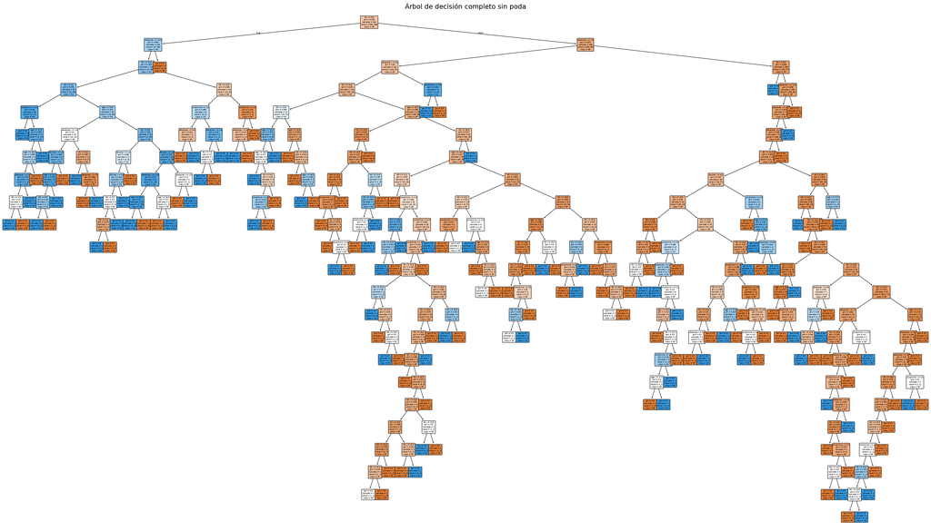

```python
from sklearn.tree import plot_tree

plt.figure(figsize=(35, 20))

plot_tree(
    arbol_completo,
    feature_names=X_train.columns,
    class_names=clases_arbol,
    filled=True,
    rounded=True,
    fontsize=5
)

plt.title(
    "Árbol de decisión completo sin poda",
    fontsize=18
)

plt.tight_layout()
plt.show()
```

[GRÁFICA 3]. Árbol de decisión completo sin poda.

Nuevamente, la clase negativa se tomará como GP y la clase positiva se tomará como MS.

```python
# Predicciones
pred_arbol_train = arbol_completo.predict(X_train)
pred_arbol_test = arbol_completo.predict(X_test)

# Probabilidades de prueba
prob_arbol_test = arbol_completo.predict_proba(X_test)

# Clases reconocidas por el árbol
clases_arbol = arbol_completo.classes_

clase_negativa = clases_arbol[0]
clase_positiva = clases_arbol[1]

# Ubicación de la clase positiva
indice_positivo = np.where(
    clases_arbol == clase_positiva
)[0][0]

# Probabilidad de la clase positiva
prob_positiva_arbol = prob_arbol_test[:, indice_positivo]

print("Clases:", clases_arbol)
print("Clase negativa:", clase_negativa)
print("Clase positiva:", clase_positiva)
```

```
Clases: ['GP' 'MS']
Clase negativa: GP
Clase positiva: MS
```

### Desempeño del árbol sin poda

```python
from sklearn.metrics import accuracy_score

accuracy_train = accuracy_score(
    y_train,
    pred_arbol_train
)

accuracy_test = accuracy_score(
    y_test,
    pred_arbol_test
)

tabla_accuracy = pd.DataFrame({
    "Conjunto": [
        "Entrenamiento",
        "Prueba"
    ],
    "Accuracy": [
        accuracy_train,
        accuracy_test
    ]
})

display(
    tabla_accuracy.style
    .hide(axis="index")
    .format({
        "Accuracy": "{:.4f}"
    })
    .set_properties(**{"text-align": "center"})
    .set_caption(
        "[TABLA 8]. Accuracy del árbol completo."
    )
)
```

[TABLA 8]. Accuracy del árbol completo.

| Conjunto | Accuracy |
| --- | --- |
| Entrenamiento | 0.9890 |
| Prueba | 0.6564 |

### Matriz de confusión

En la Gráfica 4, se observa que la matriz de confusión del árbol sin poda muestra que el modelo clasificó correctamente a 99 estudiantes de GP y 29 de MS. Sin embargo, confundió a 28 estudiantes de GP con MS y a 39 estudiantes de MS con GP. Esto indica que el árbol presenta mayor facilidad para reconocer a la clase GP, mientras que todavía tiene dificultades para identificar los estudiantes de MS.

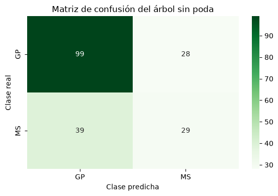

```python
from sklearn.metrics import confusion_matrix
import matplotlib.pyplot as plt
import seaborn as sns

cm_arbol = confusion_matrix(
    y_test,
    pred_arbol_test,
    labels=[clase_negativa, clase_positiva]
)

plt.figure(figsize=(6, 4))

sns.heatmap(
    cm_arbol,
    annot=True,
    fmt="d",
    cmap="Greens",
    xticklabels=[clase_negativa, clase_positiva],
    yticklabels=[clase_negativa, clase_positiva]
)

plt.title("Matriz de confusión del árbol sin poda")
plt.xlabel("Clase predicha")
plt.ylabel("Clase real")
plt.tight_layout()
plt.show()
```

[GRÁFICA 4]. Matriz de confusión del árbol sin poda.

### Métricas del árbol de decisión sin poda

En la Tabla 9, se muestra que, en prueba, el árbol sin poda presentó una exatitud balanceada de 0.6030, precisión de 0.5088, sensibilidad de 0.4265, especificidad de 0.7795, F1-score de 0.4640 y ROC-AUC de 0.5962. Aunque su sensibilidad fue mayor que la del LDA, su capacidad general de discriminación fue inferior, como lo demuestra en su ROC-AUC con un valor de 0.5962.

Estos resultados justifican la aplicación de poda, ya que el árbol completo tiene una estructura grande y copleja, pero no obtiene una mejora equivalente en los datos de prueba.

```python
from sklearn.metrics import (
    accuracy_score,
    balanced_accuracy_score,
    precision_score,
    recall_score,
    f1_score,
    roc_auc_score
)

# Convertir las clases a 0 y 1
y_test_binaria = (
    y_test.to_numpy() == clase_positiva
).astype(int)

pred_arbol_binaria = (
    pred_arbol_test == clase_positiva
).astype(int)

# Valores de la matriz de confusión
tn, fp, fn, tp = cm_arbol.ravel()

# Cálculo de métricas
accuracy_arbol = accuracy_score(
    y_test_binaria,
    pred_arbol_binaria
)

accuracy_balanceada_arbol = balanced_accuracy_score(
    y_test_binaria,
    pred_arbol_binaria
)

precision_arbol = precision_score(
    y_test_binaria,
    pred_arbol_binaria,
    zero_division=0
)

sensibilidad_arbol = recall_score(
    y_test_binaria,
    pred_arbol_binaria,
    zero_division=0
)

especificidad_arbol = (
    tn / (tn + fp)
    if (tn + fp) > 0
    else 0
)

f1_arbol = f1_score(
    y_test_binaria,
    pred_arbol_binaria,
    zero_division=0
)

auc_arbol = roc_auc_score(
    y_test_binaria,
    prob_positiva_arbol
)
```

```python
tabla_metricas_arbol = pd.DataFrame({
    "Métrica": [
        "Exactitud",
        "Exactitud balanceada",
        "Precisión",
        "Sensibilidad",
        "Especificidad",
        "F1-score",
        "ROC-AUC"
    ],
    "Resultado": [
        accuracy_arbol,
        accuracy_balanceada_arbol,
        precision_arbol,
        sensibilidad_arbol,
        especificidad_arbol,
        f1_arbol,
        auc_arbol
    ]
})

display(
    tabla_metricas_arbol.style
    .hide(axis="index")
    .format({
        "Resultado": "{:.4f}"
    })
    .set_properties(**{"text-align": "center"})
    .set_caption(
        "[TABLA 9]. Métricas del árbol de decisión sin poda."
    )
)
```

[TABLA 9]. Métricas del árbol de decisión sin poda.

| Métrica | Resultado |
| --- | --- |
| Exactitud | 0.6564 |
| Exactitud balanceada | 0.6030 |
| Precisión | 0.5088 |
| Sensibilidad | 0.4265 |
| Especificidad | 0.7795 |
| F1-score | 0.4640 |
| ROC-AUC | 0.5962 |

### Proceso de poda

La poda se realizó con el parámetro de complejidad de costo. Se obtuvieron 54 posibles valores de alpha a partir de la ruta de poda del árbol completo. Posteriormente, cada valor fue evaluado mediante validación cruzada estratificada de cinco particiones utilizando la exactitud balanceada como criterio.

En la Gráfica 5, se observa que el mejor valor encontrado fue de 0.005688. Con este valor se obtuvo una exactitud balanceada promedio cercana a 0.67 durante la validación cruzada. Un alpha igual a cero conserva el árbol completo, mientras que valores mayores eliminan ramos cuya contribución no compensa el aumento en complejidad.

```python
from sklearn.tree import DecisionTreeClassifier

# Árbol base para obtener la ruta de poda
arbol_base = DecisionTreeClassifier(
    random_state=27
)

ruta_poda = arbol_base.cost_complexity_pruning_path(
    X_train,
    y_train
)

alphas = ruta_poda.ccp_alphas

# El último alpha normalmente elimina todo el árbol
alphas = np.unique(alphas[:-1])

print("Cantidad de valores de alpha:", len(alphas))
```

```
Cantidad de valores de alpha: 54
```

```python
from sklearn.model_selection import (
    StratifiedKFold,
    cross_val_score
)

cv = StratifiedKFold(
    n_splits=5,
    shuffle=True,
    random_state=27
)

resultados_poda = []

for alpha in alphas:
    arbol_temporal = DecisionTreeClassifier(
        random_state=27,
        ccp_alpha=alpha
    )

    # Evaluación mediante validación cruzada
    scores = cross_val_score(
        arbol_temporal,
        X_train,
        y_train,
        cv=cv,
        scoring="balanced_accuracy"
    )

    # Entrenamiento para conocer su complejidad
    arbol_temporal.fit(X_train, y_train)

    resultados_poda.append({
        "Alpha": alpha,
        "Exactitud balanceada CV": scores.mean(),
        "Desviación estándar": scores.std(),
        "Profundidad": arbol_temporal.get_depth(),
        "Número de hojas": arbol_temporal.get_n_leaves()
    })

tabla_poda = pd.DataFrame(resultados_poda)
```

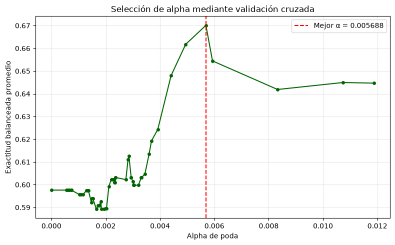

```python
indice_mejor = tabla_poda[
    "Exactitud balanceada CV"
].idxmax()

mejor_alpha = tabla_poda.loc[
    indice_mejor,
    "Alpha"
]

mejor_score_cv = tabla_poda.loc[
    indice_mejor,
    "Exactitud balanceada CV"
]

plt.figure(figsize=(8, 5))

plt.plot(
    tabla_poda["Alpha"],
    tabla_poda["Exactitud balanceada CV"],
    marker="o",
    markersize=4,
    color="darkgreen"
)

plt.axvline(
    mejor_alpha,
    color="red",
    linestyle="--",
    label=f"Mejor α = {mejor_alpha:.6f}"
)

plt.xlabel("Alpha de poda")
plt.ylabel("Exactitud balanceada promedio")
plt.title("Selección de alpha mediante validación cruzada")
plt.grid(alpha=0.3)
plt.legend()
plt.tight_layout()
plt.show()
```

[GRÁFICA 5]. Selección de alpha mediante validación cruzada.

### Efecto de la poda

La poda redujo la profunidad del árbol de 22 a 5 niveles, el número de hojas de 161 a 9 y el número total de nodos de 321 a 17. Esta reducción produjo un modelo más sencillo de visualizar e interpretar, tal como se muestra en la Gráfica 6.

```python
arbol_podado = DecisionTreeClassifier(
    random_state=27,
    ccp_alpha=mejor_alpha
)

arbol_podado.fit(X_train, y_train)

pred_podado_train = arbol_podado.predict(X_train)
pred_podado_test = arbol_podado.predict(X_test)

prob_podado_test = arbol_podado.predict_proba(
    X_test
)

clases_podado = arbol_podado.classes_

indice_positivo_podado = np.where(
    clases_podado == clase_positiva
)[0][0]

prob_positiva_podado = prob_podado_test[
    :,
    indice_positivo_podado
]
```

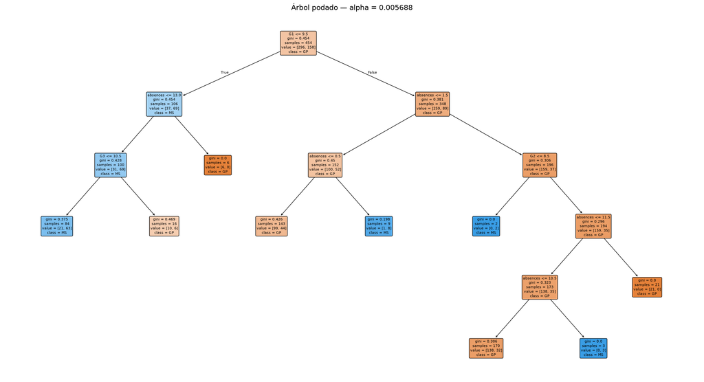

```python
from sklearn.tree import plot_tree

plt.figure(figsize=(22, 12))

plot_tree(
    arbol_podado,
    feature_names=X_train.columns,
    class_names=clases_podado,
    filled=True,
    rounded=True,
    fontsize=8
)

plt.title(
    f"Árbol podado — alpha = {mejor_alpha:.6f}",
    fontsize=16
)

plt.tight_layout()
plt.show()
```

[GRÁFICA 6]. Árbol de decisión podado.

```python
tabla_complejidad = pd.DataFrame({
    "Modelo": [
        "Árbol sin poda",
        "Árbol podado"
    ],
    "Profundidad": [
        arbol_completo.get_depth(),
        arbol_podado.get_depth()
    ],
    "Número de hojas": [
        arbol_completo.get_n_leaves(),
        arbol_podado.get_n_leaves()
    ],
    "Número de nodos": [
        arbol_completo.tree_.node_count,
        arbol_podado.tree_.node_count
    ]
})

display(
    tabla_complejidad.style
    .hide(axis="index")
    .set_properties(**{"text-align": "center"})
    .set_caption(
        "[TABLA 10]. Complejidad antes y después de la poda."
    )
)
```

[TABLA 10]. Complejidad antes y después de la poda.

| Modelo | Profundidad | Número de hojas | Número de nodos |
| --- | --- | --- | --- |
| Árbol sin poda | 22 | 161 | 321 |
| Árbol podado | 5 | 9 | 17 |

Tal como se muestra en la Tabla 11, la exactitud de entrenamiento disminuyó de 0.9890 a 0.7709, lo que signfiica que el modelo dejó de memorizar datos específicos. Al msimo tiempo, la exactitud de prueba aumentó de 0.6564 a 0.7026. Este comportamiento muestra que la poda redujo el sobreajuste y mejoró la capacidad del modelo para generalizar ante datos nuevos.

```python
from sklearn.metrics import accuracy_score

tabla_accuracy_poda = pd.DataFrame({
    "Modelo": [
        "Sin poda",
        "Sin poda",
        "Podado",
        "Podado"
    ],
    "Conjunto": [
        "Entrenamiento",
        "Prueba",
        "Entrenamiento",
        "Prueba"
    ],
    "Accuracy": [
        accuracy_score(y_train, pred_arbol_train),
        accuracy_score(y_test, pred_arbol_test),
        accuracy_score(y_train, pred_podado_train),
        accuracy_score(y_test, pred_podado_test)
    ]
})

display(
    tabla_accuracy_poda.style
    .hide(axis="index")
    .format({
        "Accuracy": "{:.4f}"
    })
    .set_properties(**{"text-align": "center"})
    .set_caption(
        "[TABLA 11]. Accuracy antes y después de la poda."
    )
)
```

[TABLA 11]. Accuracy antes y después de la poda.

| Modelo | Conjunto | Accuracy |
| --- | --- | --- |
| Sin poda | Entrenamiento | 0.9890 |
| Sin poda | Prueba | 0.6564 |
| Podado | Entrenamiento | 0.7709 |
| Podado | Prueba | 0.7026 |

### Evaluación del árbol podado

La matriz de confusión mostrada en la Gráfica 7, muestra que el árbol podado clasificó correctamente 112 estudiantes de GP y 25 estudiantes de MS. Por otro lado, clasificó incorrectamente a 15 estudiantes de GP como MS y 43 estudiantes de MS como GP. Al igual que LDA, el árbol mostró mayor facilidad para reconocer a GP debido al desbalance existente y a la superposición de las características de ambas clases.

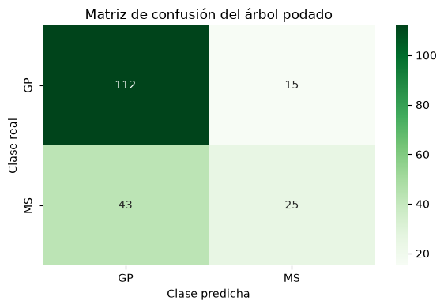

```python
cm_podado = confusion_matrix(
    y_test,
    pred_podado_test,
    labels=[clase_negativa, clase_positiva]
)

plt.figure(figsize=(6, 4))

sns.heatmap(
    cm_podado,
    annot=True,
    fmt="d",
    cmap="Greens",
    xticklabels=[clase_negativa, clase_positiva],
    yticklabels=[clase_negativa, clase_positiva]
)

plt.title("Matriz de confusión del árbol podado")
plt.xlabel("Clase predicha")
plt.ylabel("Clase real")
plt.tight_layout()
plt.show()
```

[GRÁFICA 7]. Matriz de confusión del árbol podado.

En la Tabla 12, se muestra que el árbol podado obtuvo una exactitud de 0.7026 y una exactitud balanceada de 0.6248. Para la clase MS, alcanzó una precisión de 0.6250, sensibilidad de 0.3676 y F1-score de 0.4630. Su especificidad fue de 0.8819 y su ROC_AUC alcanzó 0.6962.

Aunque la sensbilidad para MS continuó siendo baja, la poda permitió mejorar la precisión y reducir los falsos positivos. Además, el modelo podado superó tanto la exactitud como la capacidad de generalización del árbol sin podar.

```python
pred_podado_binaria = (
    pred_podado_test == clase_positiva
).astype(int)

tn, fp, fn, tp = cm_podado.ravel()

metricas_podado = {
    "Exactitud":
        accuracy_score(
            y_test_binaria,
            pred_podado_binaria
        ),

    "Exactitud balanceada":
        balanced_accuracy_score(
            y_test_binaria,
            pred_podado_binaria
        ),

    "Precisión":
        precision_score(
            y_test_binaria,
            pred_podado_binaria,
            zero_division=0
        ),

    "Sensibilidad":
        recall_score(
            y_test_binaria,
            pred_podado_binaria,
            zero_division=0
        ),

    "Especificidad":
        tn / (tn + fp)
        if (tn + fp) > 0 else 0,

    "F1-score":
        f1_score(
            y_test_binaria,
            pred_podado_binaria,
            zero_division=0
        ),

    "ROC-AUC":
        roc_auc_score(
            y_test_binaria,
            prob_positiva_podado
        )
}

tabla_metricas_podado = pd.DataFrame({
    "Métrica": metricas_podado.keys(),
    "Resultado": metricas_podado.values()
})

display(
    tabla_metricas_podado.style
    .hide(axis="index")
    .format({
        "Resultado": "{:.4f}"
    })
    .set_properties(**{"text-align": "center"})
    .set_caption(
        "[TABLA 12]. Métricas del árbol podado."
    )
)
```

[TABLA 12]. Métricas del árbol podado.

| Métrica | Resultado |
| --- | --- |
| Exactitud | 0.7026 |
| Exactitud balanceada | 0.6248 |
| Precisión | 0.6250 |
| Sensibilidad | 0.3676 |
| Especificidad | 0.8819 |
| F1-score | 0.4630 |
| ROC-AUC | 0.6962 |

## Comparación entre LDA y el árbol podado

El árbol podado obtuvo mejores resultados que LDA en la mayoría de las métricas calculadas, tal como se muestra en la Tabla 13. Su exactitud fue de 0.7026 en comparación de 0.6769 del LDA, mientras que la exactitud balanceada fue de 0.6248 en comparación con el 0.6017. También presentó mayor precisión, sensibilidad, especificidad y F1-score.

Sin embargo, LDA obtuvo un ROC-AUC de 0.7142, un poco más elevado al 0.6962 del árbol podado. Esto significa que, al considerar todos los umbrales posibles, las probilidades del LDA ordenan ligeramente mejor a las observaciones de ambas escuelas. En cambio, con el criterio de clasificación utilizado, el árbol podado general mejores resultados finales.

```python
from sklearn.metrics import (
    accuracy_score,
    balanced_accuracy_score,
    precision_score,
    recall_score,
    f1_score,
    roc_auc_score,
    confusion_matrix
)

# Clase positiva: normalmente MS
y_test_binaria = (
    y_test.to_numpy() == clase_positiva
).astype(int)

def obtener_metricas_modelo(
    nombre,
    y_pred,
    probabilidades
):
    # Convertir predicciones a 0 y 1
    y_pred_binaria = (
        np.asarray(y_pred) == clase_positiva
    ).astype(int)

    # Matriz de confusión binaria
    tn, fp, fn, tp = confusion_matrix(
        y_test_binaria,
        y_pred_binaria,
        labels=[0, 1]
    ).ravel()

    especificidad = (
        tn / (tn + fp)
        if (tn + fp) > 0
        else 0
    )

    return {
        "Modelo": nombre,
        "Exactitud": accuracy_score(
            y_test_binaria,
            y_pred_binaria
        ),
        "Exactitud balanceada": balanced_accuracy_score(
            y_test_binaria,
            y_pred_binaria
        ),
        "Precisión": precision_score(
            y_test_binaria,
            y_pred_binaria,
            zero_division=0
        ),
        "Sensibilidad": recall_score(
            y_test_binaria,
            y_pred_binaria,
            zero_division=0
        ),
        "Especificidad": especificidad,
        "F1-score": f1_score(
            y_test_binaria,
            y_pred_binaria,
            zero_division=0
        ),
        "ROC-AUC": roc_auc_score(
            y_test_binaria,
            probabilidades
        )
    }

tabla_comparacion = pd.DataFrame([
    obtener_metricas_modelo(
        "LDA",
        pred_lda,
        prob_positiva_lda
    ),
    obtener_metricas_modelo(
        "Árbol podado",
        pred_podado_test,
        prob_positiva_podado
    )
])

display(
    tabla_comparacion.style
    .hide(axis="index")
    .format({
        "Exactitud": "{:.4f}",
        "Exactitud balanceada": "{:.4f}",
        "Precisión": "{:.4f}",
        "Sensibilidad": "{:.4f}",
        "Especificidad": "{:.4f}",
        "F1-score": "{:.4f}",
        "ROC-AUC": "{:.4f}"
    })
    .highlight_max(
        subset=[
            "Exactitud",
            "Exactitud balanceada",
            "Precisión",
            "Sensibilidad",
            "Especificidad",
            "F1-score",
            "ROC-AUC"
        ],
        color="lightgreen"
    )
    .set_properties(**{"text-align": "center"})
    .set_caption(
        "[TABLA 13]. Comparación entre LDA y el árbol podado."
    )
)
```

[TABLA 13]. Comparación entre LDA y el árbol podado.

| Modelo | Exactitud | Exactitud balanceada | Precisión | Sensibilidad | Especificidad | F1-score | ROC-AUC |
| --- | --- | --- | --- | --- | --- | --- | --- |
| LDA | 0.6769 | 0.6017 | 0.5581 | 0.3529 | 0.8504 | 0.4324 | 0.7142 |
| Árbol podado | 0.7026 | 0.6248 | 0.6250 | 0.3676 | 0.8819 | 0.4630 | 0.6962 |

### Comparación de matrices de confusión

En las matrices de confusión, LDA clasificó correctamente 108 estudiantes de GP y 24 de MS, mientras que el árbol podado identificó correctamente 112 estudiantes de GP y 25 de MS. Por lo tanto, el parbol podado consiguió cuatro aciertos adicionales en GP y uno adicional en MS.

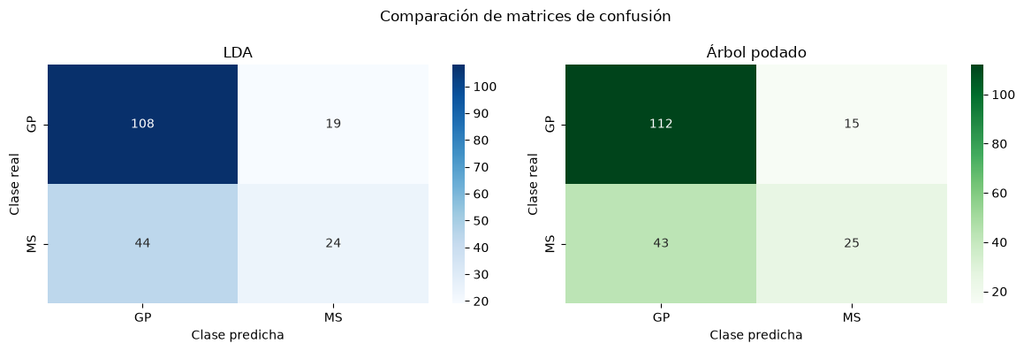

```python
fig, axes = plt.subplots(1, 2, figsize=(12, 4))

modelos = [
    ("LDA", pred_lda, "Blues"),
    ("Árbol podado", pred_podado_test, "Greens")
]

for ax, (nombre, predicciones, color) in zip(
    axes,
    modelos
):
    cm = confusion_matrix(
        y_test,
        predicciones,
        labels=[clase_negativa, clase_positiva]
    )

    sns.heatmap(
        cm,
        annot=True,
        fmt="d",
        cmap=color,
        xticklabels=[
            clase_negativa,
            clase_positiva
        ],
        yticklabels=[
            clase_negativa,
            clase_positiva
        ],
        ax=ax
    )

    ax.set_title(nombre)
    ax.set_xlabel("Clase predicha")
    ax.set_ylabel("Clase real")

plt.suptitle(
    "Comparación de matrices de confusión"
)

plt.tight_layout()
plt.show()
```

[GRÁFICA 8]. Comparación de matrices de confusión.

## Reflexión crítica

Los resultados muestran coherencia entre las visualizaciones y las métricas. La función LD1 presenta una separaión parcial, pero también cuenta con una superposición importante entre GP y MS, lo cual explica la sensibilidad reducida del LDA. Por otro lado, el árbol completo generó una estructura muy profunda que consiguió casi el 100% de exactitud en los datos de entrenamiento, pero bajó considerablemente en los datos de prueba, lo que indicó un sobreajuste.

LDA ofrece una representación compacta y una mejor capacidad global de ordenamiento según el ROC-AUC, pero depende de supuestos estadísticos que posiblemente no se cumplan con estos datos. El árbol no necesita asumir normalidad y puede representar relaciones no lineales. Además, después de la poda, el árbol de decisión produjo reglas más sencillas y un mejor desempeño bajo el criterio de clasificación utilizado.

Una limitación importante es el desbalance de clases, ya que ambos modelos favorecieron considerablemente a GP. Asimismo, las calificaciones tienen una alta correlación y la variable 'G3' solamente estaría disponible al finalizar el curso.

## Conclusión

Con base en los resultados cuantitativos y cualitativos, el árbol de decisión podado se consdera como el modelo más adecuado en este caso. Este alcanzó mejores valores de exactitud, exactitud balanceada, precisión, sensibilidad, especificidad y F1-score, además de que también tuvo una estructura más sencilla que el árbol original.

Aunque LDA obtuvo un ROC-AUC ligeramente superior, su sensibilidad para identificar estudiantes de MS fue menor. El árol podado ofreció un mejor equilibrio entre desempeño, capacidad de generalización e interpretación. No obstante, el desempeño de ambos modelos continúa siendo limitado, por lo que sería conveniente explorar otras variables, aplicar técnicas para tratar el desbalance y utilizar validación cruzada repetida en futuros análisis.

## Bibliografía

Cortez, P. (2008). Student Performance [Dataset]. UCI Machine Learning Repository. https://doi.org/10.24432/C5TG7T.